# ZEAL DTS — R/qtl (bcsft) on the TeoNAM JLM grid: LOD profile + per-family effects

The days-to-silking analog of the DTA R/qtl notebook: classic interval mapping (Haley–Knott) on the BC2S3 RTIGER ancestry mosaic (B73=A / het=H / teosinte=B), marker set + genetic map = the TeoNAM JLM 0.1-cM set (9,063 markers, TeoNAM cM — NOT computed from ZEAL); the ZEAL mosaic is projected onto those positions. Significance = genome-wide 1000-permutation LOD threshold. Candidates = the maize flowering-time gene panel (ZmCCT10/9, zcn8/12, dlf1, zag1, …) in B73 v5.

Author

Fausto Rodríguez-Zapata

Published

July 16, 2026

**What this is.** The days-to-silking (DTS) sibling of `zeal-rqtl-dta-lod-profile`. Same pipeline (`scripts/zeal_rqtl_scan.R` with `TRAIT=DTS`): a `bcsft` (BC₂S₃) cross, Haley–Knott interval mapping, a **1000-permutation** genome-wide threshold, airmine multi-peak detection, and per-family scans. Silking and anthesis (DTA) share the same flowering-time architecture, so the candidate panel is the same — the interest is whether the silking QTL colocalize with the known genes and how they differ from DTA.

**ImportantMarker set, map, and genotype — read this first**

- **No ZEAL genetic map is estimated** (excess heterozygotes make a ZEAL `est.map` unreliable), so **every cM is a TeoNAM distance**; the marker set + map is the TeoNAM JLM grid, and the ZEAL RTIGER mosaic is **projected** onto it (nearest block). Markers are named `S<chr>_<pos_v5>`.
- Genotypes are **HMM-error-corrected before the scan** (`calc.genoprob(error.prob=0.01)`); the per-taxon additive scan uses the HMM **expected dosage**. Peak CIs are the 1.5-LOD support on the real markers (matching R/qtl `lodint`).

```r
library(here)
library(data.table)
library(qtl)
library(ggplot2)
library(ggrepel)

TRAIT <- "DTS"
trait_lc <- tolower(TRAIT)
PFX <- sprintf("zeal_%s", trait_lc)
RQ <- here("results/sim/zeal/rqtl")
stopifnot(dir.exists(RQ)) # run: TRAIT=DTS Rscript scripts/zeal_rqtl_scan.R

bp_of <- function(m) as.integer(sub("^S[0-9]+_", "", m))
ci_str <- function(lbp, hbp) sprintf("%.1f–%.1f", pmin(lbp, hbp) / 1e6, pmax(lbp, hbp) / 1e6)

# candidate genes (B73 v5) for this trait, placed on the TeoNAM cM axis
cand <- fread(here(sprintf("data/teonam/%s_candidate_genes.tsv", trait_lc)))
cand[, mid := (start + end) / 2]
.nat <- fread(here("data/teonam/teonam_v5_native.tsv"))
cand[, cm := mapply(function(c, b) {
  n <- .nat[chr_v5 == c & is.finite(cm)][order(pos_v5)]
  if (nrow(n) < 2) NA_real_ else approx(n$pos_v5, n$cm, xout = b, rule = 2)$y
}, chr, mid)]
# candidate(s) whose gene body falls inside a peak's bp CI
cand_in_ci <- function(ch, lo, hi) {
  s <- cand[chr == ch & mid >= min(lo, hi) & mid <= max(lo, hi), symbol]
  if (length(s)) paste(s, collapse = ", ") else "–"
}

load_scan <- function(tag) {
  one <- fread(file.path(RQ, sprintf("%s_scanone_%s.csv", PFX, tag)))
  perms <- readRDS(file.path(RQ, sprintf("%s_perms_%s.rds", PFX, tag)))
  th <- summary(perms, alpha = c(0.05, 0.10))
  list(one = one, thr5 = as.numeric(th[1]), thr10 = as.numeric(th[2]))
}
nc <- load_scan("nocovar")
tx <- load_scan("taxon")
cross <- readRDS(file.path(RQ, sprintf("%s_cross.rds", PFX)))
NMARK <- totmar(cross)
```

```r
g <- pull.geno(cross)
meta <- data.table(
  metric = c(sprintf("individuals (%s)", TRAIT), "markers (TeoNAM JLM grid)", "chromosomes", "H / het", "B / teosinte"),
  value = c(
    sum(!is.na(pull.pheno(cross, TRAIT))), NMARK, nchr(cross),
    sprintf("%.3f", mean(g == 2, na.rm = TRUE)), sprintf("%.3f", mean(g == 3, na.rm = TRUE))
  )
)
knitr::kable(meta, caption = "Run composition. Markers = the TeoNAM JLM 0.1-cM grid; genotypes = ZEAL mosaic projected onto it.")
```

Run composition. Markers = the TeoNAM JLM 0.1-cM grid; genotypes = ZEAL mosaic projected onto it.

| metric | value |
| --- | --- |
| individuals (DTS) | 1387 |
| markers (TeoNAM JLM grid) | 9063 |
| chromosomes | 10 |
| H / het | 0.090 |
| B / teosinte | 0.020 |

## No covariate vs taxon covariate

```r
peakrow <- function(tag) fread(file.path(RQ, sprintf("%s_peaks_%s.csv", PFX, tag)))
cmp <- data.table(
  model = c("no covariate", "+ taxon (5-family)"),
  `perm 5% LOD` = round(c(nc$thr5, tx$thr5), 2),
  `perm 10% LOD` = round(c(nc$thr10, tx$thr10), 2),
  `max LOD` = round(c(max(nc$one$lod), max(tx$one$lod)), 2),
  `n QTL (FWER 0.05)` = c(nrow(peakrow("nocovar")), nrow(peakrow("taxon")))
)
knitr::kable(cmp, caption = "No covariate vs the 5-family taxon covariate: permutation thresholds, max LOD, and one-per-chromosome QTL counts.")
```

No covariate vs the 5-family taxon covariate: permutation thresholds, max LOD, and one-per-chromosome QTL counts.

| model | perm 5% LOD | perm 10% LOD | max LOD | n QTL (FWER 0.05) |
| --- | --- | --- | --- | --- |
| no covariate | 4.87 | 4.38 | 9.94 | 3 |
| + taxon (5-family) | 5.09 | 4.63 | 10.40 | 2 |

## Genome-wide LOD profile (taxon model, with the no-covariate profile behind it)

Faceted by chromosome. **Blue** = scanone + taxon covariate; **grey** = no covariate; dashed = the 1000-permutation 5% thresholds. **Dotted grey verticals** mark the flowering-time candidate genes (v5, placed on the cM axis).

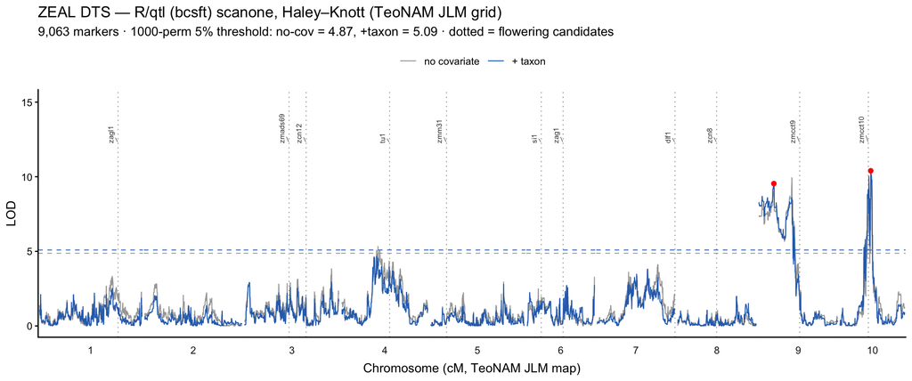

```r
prof <- rbindlist(list(
  cbind(nc$one[, .(marker, chr, pos, lod)], model = "no covariate"),
  cbind(tx$one[, .(marker, chr, pos, lod)], model = "+ taxon")
))[is.finite(lod)]
prof[, model := factor(model, levels = c("no covariate", "+ taxon"))]
sig <- prof[model == "+ taxon" & lod >= tx$thr5][, .SD[which.max(lod)], by = chr]
pal <- c("no covariate" = "grey65", "+ taxon" = "#2c6fbb")
ytop <- max(prof$lod, na.rm = TRUE)
cl <- cand[chr %in% unique(prof$chr) & is.finite(cm)]
p <- ggplot(prof, aes(pos, lod, colour = model)) +
  geom_vline(data = cl, aes(xintercept = cm), inherit.aes = FALSE, linetype = "dotted", colour = "grey55", linewidth = 0.3) +
  geom_line(linewidth = 0.4) +
  geom_hline(yintercept = nc$thr5, linetype = "dashed", colour = pal[["no covariate"]], linewidth = 0.35) +
  geom_hline(yintercept = tx$thr5, linetype = "dashed", colour = pal[["+ taxon"]], linewidth = 0.35) +
  geom_point(data = sig, colour = "red", size = 1.6) +
  ggrepel::geom_text_repel(
    data = cl, aes(x = cm, y = ytop * 1.18, label = symbol), inherit.aes = FALSE,
    size = 2.2, colour = "grey25", angle = 90, hjust = 0, direction = "x", segment.size = 0.2, min.segment.length = 0
  ) +
  expand_limits(y = ytop * 1.45) +
  facet_grid(~chr, scales = "free_x", space = "free_x", switch = "x") +
  scale_colour_manual(values = pal, name = NULL) +
  labs(
    x = "Chromosome (cM, TeoNAM JLM map)", y = "LOD",
    title = sprintf("ZEAL %s — R/qtl (bcsft) scanone, Haley–Knott (TeoNAM JLM grid)", TRAIT),
    subtitle = sprintf("%s markers · 1000-perm 5%% threshold: no-cov = %.2f, +taxon = %.2f · dotted = flowering candidates", format(NMARK, big.mark = ","), nc$thr5, tx$thr5)
  ) +
  theme_classic(base_size = 11) +
  theme(
    axis.text.x = element_blank(), axis.ticks.x = element_blank(),
    panel.spacing = unit(0.05, "lines"), strip.placement = "outside",
    strip.background = element_blank(), legend.position = "top"
  ) +
  scale_x_continuous(expand = c(0.01, 0))
ggsave(file.path(RQ, sprintf("%s_lod_profile.png", PFX)), p, width = 11, height = 4.6, dpi = 200, bg = "white")
p
```

## Candidate gene registry

Curated evidence for each **candidate** (tier, causal direction, evidence type, phenotype, and a DOI link) from the tracked registry (`reference/candidate_genes.csv` × `candidate_evidence.csv`). These are the genes marked on the LOD profile above; loci without B73 v5 coordinates still appear here but are not plotted.

```r
source(here::here("scripts/teonam_notebook_plots.R"))
candidate_table(TRAIT)
```

Candidate genes for DTS from the tracked registry (reference/candidate_*.csv): 11 loci (11 mapped to B73 v5, 0 unmapped). DOI links where curated; “TODO” = evidence not yet curated.

| gene | full name | locus | tier | direction | evidence | phenotype / note | reference |
| --- | --- | --- | --- | --- | --- | --- | --- |
| *zagl1* |  | 1:283.8 Mb |  |  |  |  | TODO |
| *zmads69* |  | 3:161.2 Mb |  |  |  |  | TODO |
| *zcn12* |  | 3:202.8 Mb |  |  |  |  | TODO |
| *tu1* | tu1 (tunicate1 / ZMM19 / MADS19) | 4:183.9 Mb |  |  |  |  | TODO |
| *zmm31* |  | 5:7.4 Mb |  |  |  |  | TODO |
| *si1* |  | 6:94.5 Mb |  |  |  |  | TODO |
| *zag1* |  | 6:142.7 Mb |  |  |  |  | TODO |
| *dlf1* |  | 7:184.5 Mb |  |  |  |  | TODO |
| *zcn8* |  | 8:126.7 Mb |  |  |  |  | TODO |
| *zmcct9* |  | 9:121.0 Mb |  |  |  |  | TODO |
| *zmcct10* |  | 10:96.2 Mb |  |  |  |  | TODO |

## Significant peaks (taxon model, α = 0.05) — one per chromosome, with candidate colocalization

R/qtl’s `summary()` reports one peak per chromosome. The 1.5-LOD CI is in v5 Mb; **candidate in CI** lists any flowering gene whose body falls inside.

```r
cipk <- fread(file.path(RQ, sprintf("%s_peaks_ci_taxon.csv", PFX)))
if (nrow(cipk) == 0) {
  cat("No genome-wide significant peaks.")
} else {
  knitr::kable(
    cipk[order(chr, -lod), .(
      chr,
      `pos (cM)` = round(pos, 1), `pos (Mb)` = round(bp_of(marker) / 1e6, 1),
      LOD = round(lod, 2), pval, marker,
      `1.5-LOD CI (Mb)` = ci_str(ci_left, ci_right),
      `candidate in CI` = mapply(cand_in_ci, chr, ci_left, ci_right)
    )],
    caption = "Genome-wide significant QTL (taxon model), 1.5-LOD CI in v5 Mb, with any flowering candidate inside."
  )
}
```

Genome-wide significant QTL (taxon model), 1.5-LOD CI in v5 Mb, with any flowering candidate inside.

| chr | pos (cM) | pos (Mb) | LOD | pval | marker | 1.5-LOD CI (Mb) | candidate in CI |
| --- | --- | --- | --- | --- | --- | --- | --- |
| 9 | 28.0 | 12.4 | 9.54 | 0 | S9_12409400 | 1.9–37.2 | – |
| 10 | 56.8 | 117.7 | 10.40 | 0 | S10_117670536 | 92.0–123.6 | zmcct10 |

### Multi-peak refinement (airmine `refine_peaks`)

Multiple linked QTL per chromosome, via Akima interpolation + `pracma::findpeaks` + interval-graph deconvolution (trough-merge to avoid over-splitting broad pericentromeric peaks). CIs are the real-marker 1.5-LOD support.

```r
refined <- function(tag) {
  r <- fread(file.path(RQ, sprintf("%s_peaks_refined_%s.csv", PFX, tag)))
  if (nrow(r) == 0) {
    return(r)
  }
  r[order(chr, -lod), .(
    chr,
    `pos (cM)` = round(pos, 1), `pos (Mb)` = round(bp_of(marker) / 1e6, 1),
    LOD = round(lod, 2), `perm 5% thr` = round(thresh, 2), marker,
    `1.5-LOD CI (Mb)` = ci_str(ci_left, ci_right),
    `candidate in CI` = mapply(cand_in_ci, chr, ci_left, ci_right)
  )]
}
rt <- refined("taxon")
if (nrow(rt) == 0) cat("No refined peaks.") else knitr::kable(rt, caption = sprintf("Refined multi-peak QTL, taxon model (%d QTL across %d chromosomes).", nrow(rt), uniqueN(rt$chr)))
```

Refined multi-peak QTL, taxon model (5 QTL across 2 chromosomes).

| chr | pos (cM) | pos (Mb) | LOD | perm 5% thr | marker | 1.5-LOD CI (Mb) | candidate in CI |
| --- | --- | --- | --- | --- | --- | --- | --- |
| 9 | 28.0 | 12.4 | 9.54 | 5.09 | S9_12409400 | 1.9–14.0 | – |
| 9 | 60.8 | 32.3 | 8.59 | 5.09 | S9_32344256 | 22.3–47.4 | – |
| 10 | 56.8 | 117.7 | 10.40 | 5.09 | S10_117670536 | 117.7–123.6 | – |
| 10 | 53.3 | 101.4 | 10.02 | 5.09 | S10_101418767 | 88.5–104.5 | zmcct10 |
| 10 | 46.7 | 76.8 | 5.79 | 5.09 | S10_76811299 | 33.9–78.2 | – |

## Per-taxon (family-resolved), additive-only with QC

Each taxon’s NILs scanned separately on the HMM expected dosage (per-family filters: fraction introgressed > 0.05 & ≥ 3 samples per present genotype class), with the family’s own 1000-perm 5% threshold.

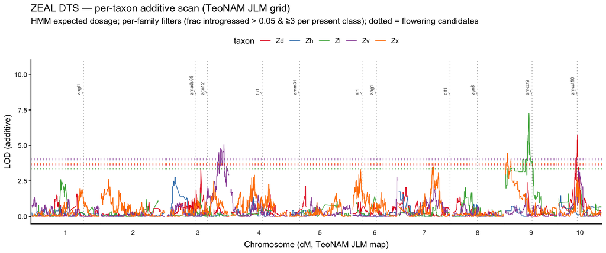

```r
bt <- fread(file.path(RQ, sprintf("%s_scanone_by_taxon.csv", PFX)))[is.finite(lod)]
pal5 <- c(Zd = "#E41A1C", Zh = "#377EB8", Zl = "#4DAF4A", Zv = "#984EA3", Zx = "#FF7F00")
ytop_bt <- max(bt$lod, na.rm = TRUE)
pt <- ggplot(bt, aes(pos, lod, colour = taxon)) +
  geom_vline(data = cl, aes(xintercept = cm), inherit.aes = FALSE, linetype = "dotted", colour = "grey55", linewidth = 0.3) +
  ggrepel::geom_text_repel(
    data = cl, aes(x = cm, y = ytop_bt * 1.18, label = symbol), inherit.aes = FALSE,
    size = 2.2, colour = "grey25", angle = 90, hjust = 0, direction = "x", segment.size = 0.2, min.segment.length = 0
  ) +
  expand_limits(y = ytop_bt * 1.45) +
  geom_line(linewidth = 0.4) +
  geom_hline(data = unique(bt[, .(taxon, thr5)]), aes(yintercept = thr5, colour = taxon), linetype = "dotted", linewidth = 0.4, show.legend = FALSE) +
  facet_grid(~chr, scales = "free_x", space = "free_x", switch = "x") +
  scale_colour_manual(values = pal5, name = "taxon") +
  labs(
    x = "Chromosome (cM, TeoNAM JLM map)", y = "LOD (additive)",
    title = sprintf("ZEAL %s — per-taxon additive scan (TeoNAM JLM grid)", TRAIT),
    subtitle = "HMM expected dosage; per-family filters (frac introgressed > 0.05 & ≥3 per present class); dotted = flowering candidates"
  ) +
  theme_classic(base_size = 11) +
  theme(
    axis.text.x = element_blank(), axis.ticks.x = element_blank(),
    panel.spacing = unit(0.05, "lines"), strip.placement = "outside",
    strip.background = element_blank(), legend.position = "top"
  ) +
  scale_x_continuous(expand = c(0.01, 0))
ggsave(file.path(RQ, sprintf("%s_lod_by_taxon.png", PFX)), pt, width = 11, height = 4.6, dpi = 200, bg = "white")
pt
```

```r
btpk <- bt[,
  {
    i <- which.max(lod)
    ch <- chr[i]
    L <- lod[i]
    ins <- .SD[chr == ch][lod >= L - 1.5]
    lo <- min(bp_of(ins$marker))
    hi <- max(bp_of(ins$marker))
    .(
      chr = ch, `pos (cM)` = round(pos[i], 1), `pos (Mb)` = round(bp_of(marker[i]) / 1e6, 1),
      marker = marker[i], `max LOD` = round(L, 2), `perm 5% thr` = round(thr5[1], 2),
      sig = fifelse(L > thr5[1], "yes", "no"),
      `1.5-LOD CI (Mb)` = sprintf("%.1f–%.1f", lo / 1e6, hi / 1e6),
      `candidate in CI` = cand_in_ci(ch, lo, hi)
    )
  },
  by = taxon
][order(-`max LOD`)]
knitr::kable(btpk, caption = "Genome-wide additive peak per taxon, with the per-taxon 1000-perm 5% threshold and any flowering candidate in the CI. 'sig' = the family's peak exceeds its own threshold.")
```

Genome-wide additive peak per taxon, with the per-taxon 1000-perm 5% threshold and any flowering candidate in the CI. ‘sig’ = the family’s peak exceeds its own threshold.

| taxon | chr | pos (cM) | pos (Mb) | marker | max LOD | perm 5% thr | sig | 1.5-LOD CI (Mb) | candidate in CI |
| --- | --- | --- | --- | --- | --- | --- | --- | --- | --- |
| Zl | 9 | 67.0 | 93.6 | S9_93573588 | 7.25 | 3.35 | yes | 81.5–98.5 | – |
| Zd | 10 | 53.1 | 100.9 | S10_100917157 | 5.73 | 3.63 | yes | 93.0–104.6 | zmcct10 |
| Zv | 3 | 160.8 | 230.3 | S3_230298803 | 5.06 | 4.04 | yes | 222.8–230.6 | – |
| Zx | 9 | 6.5 | 4.5 | S9_4522630 | 4.47 | 3.74 | yes | 2.2–9.1 | – |
| Zh | 3 | 22.4 | 6.4 | S3_6385561 | 2.75 | 3.98 | no | 4.7–27.9 | – |

### Per-taxon multi-peak refinement

```r
btr <- fread(file.path(RQ, sprintf("%s_peaks_refined_by_taxon.csv", PFX)))
if (nrow(btr) == 0) {
  cat("No per-taxon refined peaks cleared the per-family thresholds.")
} else {
  knitr::kable(
    btr[order(taxon, chr, -lod), .(
      taxon, chr,
      `pos (cM)` = round(pos, 1), `pos (Mb)` = round(bp_of(marker) / 1e6, 1),
      LOD = round(lod, 2), `perm 5% thr` = round(thr5, 2), marker,
      `1.5-LOD CI (Mb)` = ci_str(ci_left, ci_right),
      `candidate in CI` = mapply(cand_in_ci, chr, ci_left, ci_right)
    )],
    caption = sprintf("Refined per-taxon multi-peak QTL (%d QTL across %d families).", nrow(btr), uniqueN(btr$taxon))
  )
}
```

Refined per-taxon multi-peak QTL (5 QTL across 4 families).

| taxon | chr | pos (cM) | pos (Mb) | LOD | perm 5% thr | marker | 1.5-LOD CI (Mb) | candidate in CI |
| --- | --- | --- | --- | --- | --- | --- | --- | --- |
| Zd | 10 | 53.1 | 100.9 | 5.73 | 3.63 | S10_100917157 | 92.0–105.1 | zmcct10 |
| Zl | 9 | 67.0 | 93.6 | 7.25 | 3.35 | S9_93573588 | 79.8–99.8 | – |
| Zv | 3 | 160.8 | 230.3 | 5.06 | 4.04 | S3_230298803 | 222.6–230.7 | – |
| Zx | 7 | 96.8 | 166.2 | 3.78 | 3.74 | S7_166209939 | 162.3–174.9 | – |
| Zx | 9 | 6.5 | 4.5 | 4.47 | 3.74 | S9_4522630 | 2.1–9.2 | – |

## Allele effect at the strongest per-taxon peak, by taxon

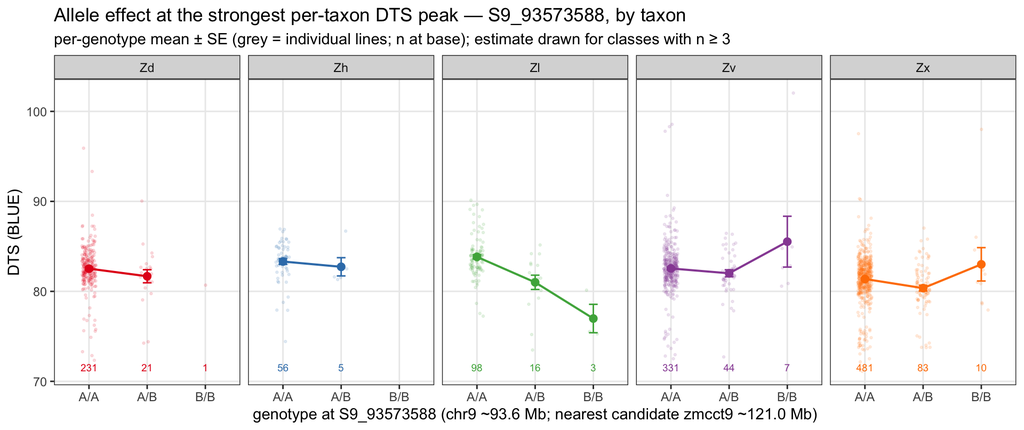

```r
top <- btpk[sig == "yes"][which.max(`max LOD`)]
mk <- top$marker
gm <- pull.geno(cross)[, mk]
yv <- as.numeric(pull.pheno(cross, TRAIT))
ids <- as.character(pull.pheno(cross, "id"))
ss <- fread(here("data/zeal/samplesheet_3way.csv"))[, .(pedigree, taxon)]
d <- data.table(
  taxon = ss[match(ids, pedigree), taxon],
  geno = factor(c("A/A", "A/B", "B/B")[gm], levels = c("A/A", "A/B", "B/B")), y = yv
)[!is.na(y) & !is.na(geno) & taxon %in% names(pal5)]
summ <- d[, .(mean = mean(y), se = sd(y) / sqrt(.N), n = .N), by = .(taxon, geno)]
shown <- summ[n >= 3]
ncand <- cand[chr == top$chr][which.min(abs(mid - bp_of(mk)))]
ef <- ggplot(d, aes(geno, y, colour = taxon)) +
  geom_jitter(width = 0.12, alpha = 0.12, size = 0.5) +
  geom_line(data = shown, aes(y = mean, group = taxon), linewidth = 0.7) +
  geom_point(data = shown, aes(y = mean), size = 2.2) +
  geom_errorbar(data = shown, aes(y = mean, ymin = mean - se, ymax = mean + se), width = 0.15) +
  geom_text(data = summ, aes(label = n), y = min(d$y), vjust = 0, size = 2.5, show.legend = FALSE) +
  facet_wrap(~taxon, nrow = 1) +
  scale_colour_manual(values = pal5, guide = "none") +
  labs(
    x = sprintf("genotype at %s (chr%d ~%.1f Mb; nearest candidate %s ~%.1f Mb)", mk, top$chr, bp_of(mk) / 1e6, ncand$symbol, ncand$mid / 1e6),
    y = sprintf("%s (BLUE)", TRAIT),
    title = sprintf("Allele effect at the strongest per-taxon %s peak — %s, by taxon", TRAIT, mk),
    subtitle = "per-genotype mean ± SE (grey = individual lines; n at base); estimate drawn for classes with n ≥ 3"
  ) +
  theme_bw(base_size = 11) +
  theme(panel.grid.minor = element_blank())
ggsave(file.path(RQ, sprintf("%s_%s_effect.png", PFX, mk)), ef, width = 10, height = 4.2, dpi = 200, bg = "white")
ef
```

**Read.** Effect size (days) and statistical support (LOD/n) are separate. `A/A` = B73, `A/B` = het, `B/B` = homozygous teosinte. Colocalization with a flowering candidate (the “candidate in CI” columns) is suggestive, not proof — the CIs are multi-Mb at this mapping resolution.